# How to grow a tree?

03-06-2022

## Modelling

A modelling algorithm finds a relationship between response variable and input variable.

Source: Minguillón, J., Meneses, J., Aibar, E., Ferran-Ferrer, N., and Fàbregues, S. (2021). Exploring the gender gap in the Spanish Wikipedia: Differences in engagement and editing practices. PLOS ONE 16, e0246702. https://doi.org/10.1371/journal.pone.0246702.

## Available data

C_api: gender (male, female, unknown)

pagesWomen: number of edits in pages related to women

NEds: total number of editions

## Basic terms

\(y\): response variables.

\(X\): input variable with \(n\) features.

\[y \sim X\]

\[ y = \beta_1 x_1 + \dots + \beta_i x_i + \dots + \beta_n x_n \]

## Available data

| C_api | NEds | pagesWomen |
| --- | --- | --- |
| female | 233 | 0 |
| female | 87 | 0 |
| female | 157 | 0 |
| female | 128 | 0 |
| female | 77 | 0 |
| female | 144 | 0 |

## Available data

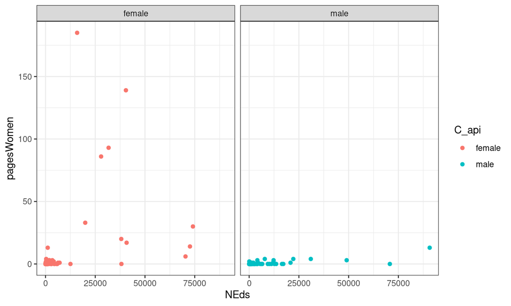

## Without faceting

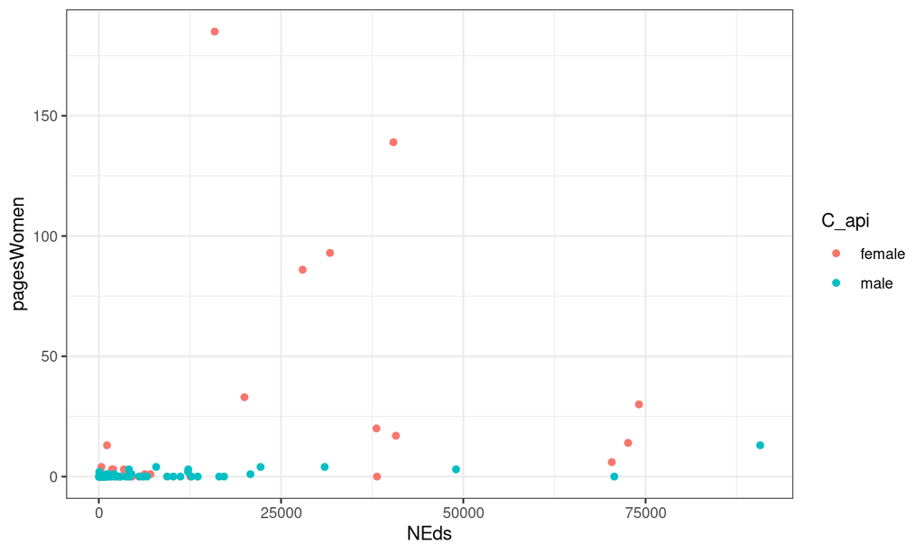

## Partitioning

Can we divide data into a subsets based on the value of NEds and pagesWomen to distinguish between male and female?

## Partitioning

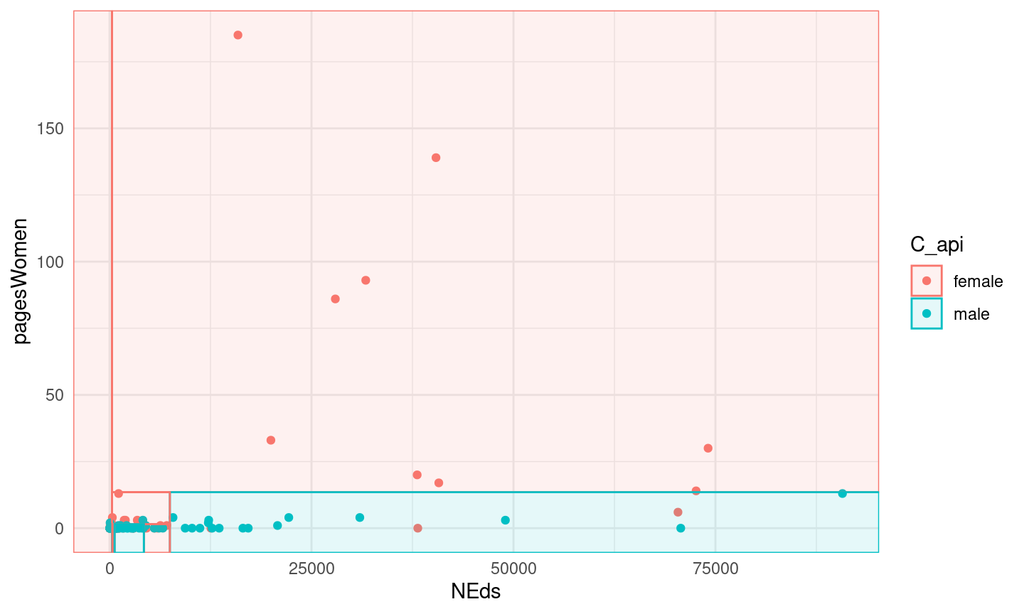

## Partitioning

Cen we represent the partition in a simpler way?

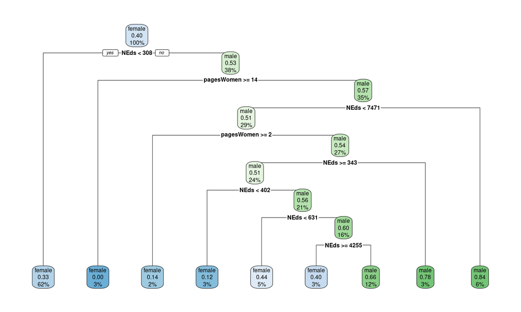

## How to grow it?

\[ y = \beta_1 x_1 + \dots + \beta_i x_i + \dots + \beta_n x_n \]

\(M\): number of regions

## How to grow it?

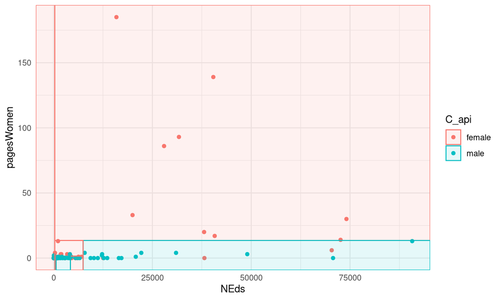

## How to grow it?

\[ y = \beta_1 x_1 + \dots + \beta_i x_i + \dots + \beta_n x_n \]

\(M\): number of regions

\[ y = \sum^{M}_{m = 1} c_m \left(x \in R_M \right) \]

\[ \hat c_m = \textrm{ave} \left(y_i | x_i \in R_M \right) \]

## How to grow it?

Next steps:

- greedy algorithm for finding optimal splits
- pruning (collapsing nodes, where their bring very little to the fit)

## Reading more:

Section 9.2, Elements of statistical learning (https://hastie.su.domains/Papers/ESLII.pdf)